# Lead scoring con IA: prioriza tus leads según ROI

Author

BI Evolution

## Resumen ejecutivo

Este análisis construye un **modelo de Lead Scoring con IA** para:

- Asignar a cada prospecto una **probabilidad de conversión**.
- Priorizar el trabajo comercial donde **más retorno genera**.
- Cuantificar el impacto en términos de **ROI**, usando una matriz de confusión con costos.

Se probaron varios modelos (Regresión Logística, Random Forest, XGBoost y SVM con validación cruzada) y se seleccionó el que **mayor retorno económico esperado** entrega.

## 1. Resultado principal del modelo

### 1.1. Modelo ganador y desempeño global

En la práctica, el equipo comercial solo puede realizar alrededor de 500 llamadas personalizadas en el periodo. Comparamos dos estrategias:

• “Sin modelo: 500 llamadas al azar / orden de llegada, el resto recibe solo campañas genéricas.” • “Con modelo IA: 500 llamadas a los leads con mayor probabilidad de conversión según el modelo de Lead Scoring.”

Así el directorio entiende que:

• No es “magia del algoritmo”. • Estás comparando dos formas de usar la misma capacidad comercial.

Comparación de resultados: sin modelo vs. modelo de Lead Scoring con IA

| Escenario | ROI estimado (S/.) |
| --- | --- |
| Sin modelo (500 llamadas al azar) | 10100 |
| Con modelo IA (500 mejores leads) | 22300 |

### 1.2. Matriz de confusión con costos asociados

Matriz de confusión del modelo ganador (set de prueba)

|  | Predicho: No | Predicho: Sí |
| --- | --- | --- |
| Real: No | 974 | 25 |
| Real: Sí | 351 | 149 |

Impacto económico por tipo de resultado (TP, TN, FP, FN)

[output not shown]

Interpretación en términos de negocio:

- **TP (Predicción = Sí, Real = Sí)** → clientes que sí iban a comprar y el modelo marcó como prioridad.
  - Aportan **ingresos directos** (S/. 200 por caso en este ejemplo).
- **TN (Predicción = No, Real = No)** → leads sin intención donde **evitamos gastar esfuerzo**.
  - Representan **ahorro de costos** (S/. 5 por caso).
- **FP (Predicción = Sí, Real = No)** → leads que no convierten pero sí se contactan.
  - Generan un **costo comercial** (S/. –10 por caso).
- **FN (Predicción = No, Real = Sí)** → leads que iban a convertir pero no fueron priorizados.
  - Son la **pérdida más costosa** (S/. –200 por caso).

El ROI final del modelo se obtiene multiplicando cada tipo de resultado por su valor/costo y sumando.

### 1.3. Comparativa visual del ROI: sin modelo vs. con IA

A continuación se muestra una comparación directa del retorno económico entre:

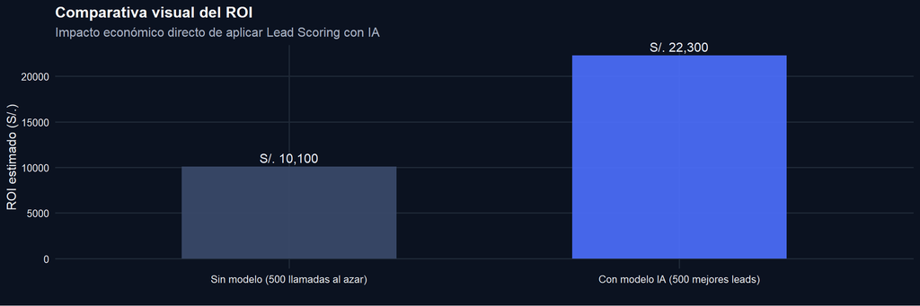

## 2. Datos utilizados

A continuación, una vista rápida de la base que alimenta el modelo:

Muestra de registros utilizados para el modelo de Lead Scoring

| id_prospecto | edad | genero | ingresos_mensuales | canal_origen | interes_producto | nivel_interes | tiempo_respuesta_min | interacciones_previas | visitas_web | open_rate | email_score | tiempo_decision_dias | estado_embudo | monto_estimado | dias_desde_ultimo_contacto | canal_preferido | convirtio |
| --- | --- | --- | --- | --- | --- | --- | --- | --- | --- | --- | --- | --- | --- | --- | --- | --- | --- |
| 1 | 28 | M | 3312 | Referido | Servicio Premium | 3 | 3 | 3 | 2 | 0.74 | 63 | 33 | Oportunidad | 2219 | 1 | Email | No |
| 2 | 43 | F | 3205 | Facebook | Servicio A | 3 | 7 | 2 | 4 | 0.61 | 98 | 8 | Contacto Nuevo | 5920 | 60 | Llamada | No |
| 3 | 31 | M | 5972 | Referido | Servicio A | 5 | 53 | 3 | 8 | 0.92 | 94 | 6 | Contacto Nuevo | 5744 | 32 | Email | Sí |
| 4 | 26 | M | 6486 | Referido | Servicio A | 3 | 34 | 5 | 1 | 0.86 | 62 | 1 | Contacto Nuevo | 5453 | 12 | WhatsApp | No |
| 5 | 47 | F | 5294 | Referido | Servicio C | 4 | 30 | 0 | 2 | 0.60 | 71 | 3 | Interesado | 4835 | 65 | Llamada | No |
| 6 | 30 | M | 3678 | Google Ads | Servicio A | 4 | 14 | 1 | 5 | 0.61 | 48 | 17 | Interesado | 3231 | 25 | Email | No |

Estas variables incluyen información de **perfil** (por ejemplo, edad, ingresos) y de **comportamiento** (visitas, aperturas de email, interacciones, tiempos de respuesta, etc.), más la variable objetivo `convirtio`.

## 3. Modelos evaluados y criterio de selección

Se evaluaron los siguientes algoritmos de clasificación binaria:

- **Regresión logística**
- **Random Forest**
- **XGBoost**
- **SVM (Support Vector Machine)**

Todos se entrenaron con **validación cruzada** (5-fold) y métrica principal **ROC**.

Desempeño comparativo de los modelos (ROC medio en validación cruzada)

| Modelo | ROC mínimo (CV) | ROC medio (CV) | ROC máximo (CV) |
| --- | --- | --- | --- |
| Regresión logística | 0.862 | 0.876 | 0.903 |
| XGBoost | 0.840 | 0.869 | 0.887 |
| SVM | 0.829 | 0.859 | 0.875 |
| Random Forest | 0.825 | 0.841 | 0.881 |

El modelo seleccionado (Regresión logística) no solo tiene **buen ROC**, sino que además ofrece el **mejor ROI esperado** una vez que incorporamos los costos/beneficios de TP, TN, FP y FN.

## 4. Cómo se interpreta esto para el directorio

En términos simples:

- El modelo asigna a cada lead una **probabilidad de conversión**.
- Según ese score, definimos **qué leads priorizar**, cuáles dejar en segundo plano y cuáles no vale la pena atacar.
- En vez de medir solo “accuracy”, medimos **dinero**:
  - ¿Cuánto ganamos adicionalmente por priorizar bien?
  - ¿Cuánto ahorramos al dejar de insistir sobre leads de bajo valor?
  - ¿Cuánto dejamos de perder al reducir los FN (clientes que se escapaban)?

El resultado: un proceso comercial que **usa datos para decidir a quién llamar primero**, con un **ROI cuantificado** y repetible mes a mes.

### 4.1. ¿Por qué *accuracy* NO sirve aquí?

Para evitar tecnicismos y enfocarnos en negocio:

> **Accuracy NO sirve en este caso**  
> Porque trata igual a un TP y a un TN.

> Pero en negocio, **un FN cuesta muchísimo más que un FP**.

> Por eso usamos un enfoque económico basado en ROI, con TP, TN, FP y FN ponderados por su impacto.

## 5. Próximos pasos sugeridos

1. **Integrar el score en el CRM.**  
   Marcar cada lead como **Alta / Media / Baja prioridad** y que el equipo comercial lo vea en su pantalla.
2. **Definir scripts de contacto por nivel de score.**
   - Alta prioridad: más intentos de contacto, canales directos (llamada / WhatsApp) y ofertas fuertes.
   - Media prioridad: seguimiento equilibrado, emails más espaciados.
   - Baja prioridad: campañas masivas, newsletters, poca intervención humana.
3. **Medir resultados reales con el modelo.**  
   Comparar, después de 1–2 meses, la **tasa de cierre y ticket promedio** por nivel de score vs. la gestión anterior sin modelo.  
   Esto valida en la práctica el ROI estimado con la matriz de confusión.
4. **Recalibrar costos y umbrales.**  
   Ajustar los valores de:
   - cuánto gana el negocio con un TP,
   - cuánto “cuesta” un FP (tiempo del vendedor),
   - cuánto duele un FN (venta perdida),  
     para que el modelo priorice según la realidad del negocio.
5. **Automatizar campañas según el scoring.**  
   Conectar el modelo a tu herramienta de marketing/ventas para lanzar **workflows automáticos**: emails, tareas de contacto, recordatorios y cambios de etapa según el score.